# ITE machine learning with Tidymodels

# Glimpse of prior ITE scores (dataset)

|  | Resident | PGY1_percentile | PGY1_score | PGY2_percentile | PGY2_score | PGY3_percentile | PGY3_score | Pass |
| --- | --- | --- | --- | --- | --- | --- | --- | --- |
| 1 | 1 | 47 | 57 | 64 | 68 | 73 | 74 | Yes |
| 2 | 2 | 72 | 63 | 55 | 66 | 38 | 67 | Yes |
| 3 | 3 | 24 | 51 | 14 | 57 | 38 | 67 | Yes |
| 4 | 4 | 87 | 68 | 90 | 75 | 77 | 75 | Yes |
| 5 | 5 | 5 | 44 | 14 | 57 | 6 | 57 | Yes |
| 6 | 6 | 98 | 78 | 68 | 69 | 77 | 75 | Yes |
| 7 | 7 | 11 | 47 | 11 | 56 | 10 | 59 | Yes |
| 8 | 8 | 20 | 50 | 24 | 60 | 2 | 53 | No |
| 9 | 9 | 3 | 42 | 14 | 57 | 3 | 54 | No |
| 10 | 10 | 43 | 59 | 20 | 60 | 9 | 62 | No |

# Comparing ITE scores & percentile between passed and failed learners by their training years

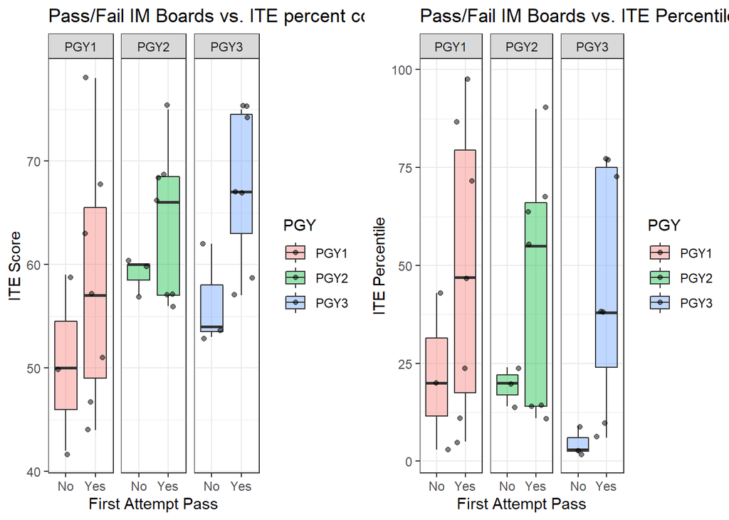

# Splitting data to training and testing

This is our first 6 rows of training dataset:

```
## # A tibble: 6 x 7
##   PGY1_percentile PGY1_score PGY2_percentile PGY2_score PGY3_percentile
##             <dbl>      <dbl>           <dbl>      <dbl>           <dbl>
## 1              20         50              24         60               2
## 2               3         42              14         57               3
## 3              47         57              64         68              73
## 4              72         63              55         66              38
## 5              24         51              14         57              38
## 6              98         78              68         69              77
## # ... with 2 more variables: PGY3_score <dbl>, Pass <fct>
```

# Preprocessing / feature engineering

Taking a look at our preprocessed training data Since there usually is less Fail in a program, will use upsampling to increase this number so that we can assess our training model better As you can see now we have 5 fails and 5 pass

|  | PGY1_percentile | PGY1_score | PGY2_percentile | PGY2_score | PGY3_percentile | PGY3_score | Pass |
| --- | --- | --- | --- | --- | --- | --- | --- |
| 1 | -0.921048027803839 | -1.01840210974981 | -0.773725376228509 | -0.820303112429596 | -0.725521068686909 | -0.765669529874326 | No |
| 2 | -0.377373844725184 | -0.277746029931765 | -0.323885041211934 | -0.205075778107399 | -0.758801851654199 | -0.876636128406838 | No |
| 3 | -0.921048027803839 | -1.01840210974981 | -0.773725376228509 | -0.820303112429596 | -0.725521068686909 | -0.765669529874326 | No |
| 4 | -0.377373844725184 | -0.277746029931765 | -0.323885041211934 | -0.205075778107399 | -0.758801851654199 | -0.876636128406838 | No |
| 5 | -0.377373844725184 | -0.277746029931765 | -0.323885041211934 | -0.205075778107399 | -0.758801851654199 | -0.876636128406838 | No |
| 6 | 0.486108681340915 | 0.370328039909021 | 1.47547629885437 | 1.43553044675179 | 1.60413373902335 | 1.4536624407759 | Yes |
| 7 | 1.28562953880953 | 0.925820099772552 | 1.07061999733945 | 1.02537889053699 | 0.43930633516822 | 0.676896251048318 | Yes |
| 8 | -0.249450507530207 | -0.18516401995451 | -0.773725376228509 | -0.820303112429596 | 0.43930633516822 | 0.676896251048318 | Yes |
| 9 | 2.11713123057688 | 2.31455024943138 | 1.655412432861 | 1.64060622485919 | 1.73725687089251 | 1.56462903930841 | Yes |
| 10 | -0.665201353413884 | -0.555492059863531 | -0.908677476733482 | -1.02537889053699 | -0.492555587915883 | -0.210836537211771 | Yes |

# Preparing our cross validation (model validation dataset) (k=5, repeats =5)

```
## #  5-fold cross-validation repeated 5 times using stratification
## # A tibble: 25 x 3
##    splits        id      id2
##    <list>        <chr>   <chr>
##  1 <split [5/2]> Repeat1 Fold1
##  2 <split [5/2]> Repeat1 Fold2
##  3 <split [6/1]> Repeat1 Fold3
##  4 <split [6/1]> Repeat1 Fold4
##  5 <split [6/1]> Repeat1 Fold5
##  6 <split [5/2]> Repeat2 Fold1
##  7 <split [5/2]> Repeat2 Fold2
##  8 <split [6/1]> Repeat2 Fold3
##  9 <split [6/1]> Repeat2 Fold4
## 10 <split [6/1]> Repeat2 Fold5
## # ... with 15 more rows
```

What this does is it uses our training set, group our training dataset 5 different times and uses 1 set as a test set. Then repeat 5 more times.

# Training using different models

Please remember to install the appropriate packages for the model you want to train with. Please take a look at available models https://www.tidymodels.org/find/parsnip/

## K nearest neighbor

```
##           Truth
## Prediction No Yes
##        No   5   5
##        Yes  5  20
```

|  | .metric | .estimator | mean | n | std_err | .config |
| --- | --- | --- | --- | --- | --- | --- |
| 1 | accuracy | binary | 0.74 | 25 | 0.0714142842854285 | Preprocessor1_Model1 |
| 2 | roc_auc | binary | 0.8 | 10 | 0.0816496580927726 | Preprocessor1_Model1 |
| 3 | sens | binary | 0.5 | 10 | 0.166666666666667 | Preprocessor1_Model1 |
| 4 | spec | binary | 0.8 | 25 | 0.0816496580927726 | Preprocessor1_Model1 |

## Naive Bayes

```
##           Truth
## Prediction No Yes
##        No   8   8
##        Yes  2  17
```

|  | .metric | .estimator | mean | n | std_err | .config |
| --- | --- | --- | --- | --- | --- | --- |
| 1 | accuracy | binary | 0.68 | 25 | 0.0860232526704263 | Preprocessor1_Model1 |
| 2 | roc_auc | binary | 1 | 10 | 0 | Preprocessor1_Model1 |
| 3 | sens | binary | 0.8 | 10 | 0.133333333333333 | Preprocessor1_Model1 |
| 4 | spec | binary | 0.68 | 25 | 0.0952190457139047 | Preprocessor1_Model1 |

## Logistic Regression

```
##           Truth
## Prediction No Yes
##        No   5  14
##        Yes  5  11
```

|  | .metric | .estimator | mean | n | std_err | .config |
| --- | --- | --- | --- | --- | --- | --- |
| 1 | accuracy | binary | 0.42 | 25 | 0.0850490054811538 | Preprocessor1_Model1 |
| 2 | roc_auc | binary | 0.75 | 10 | 0.111803398874989 | Preprocessor1_Model1 |
| 3 | sens | binary | 0.5 | 10 | 0.166666666666667 | Preprocessor1_Model1 |
| 4 | spec | binary | 0.44 | 25 | 0.101324561023804 | Preprocessor1_Model1 |

## Random Forest (without tuning)

```
##           Truth
## Prediction No Yes
##        No   6  16
##        Yes  4   9
```

|  | .metric | .estimator | mean | n | std_err | .config |
| --- | --- | --- | --- | --- | --- | --- |
| 1 | accuracy | binary | 0.4 | 25 | 0.0763762615825973 | Preprocessor1_Model1 |
| 2 | roc_auc | binary | 0.5 | 10 | 0 | Preprocessor1_Model1 |
| 3 | sens | binary | 0.6 | 10 | 0.163299316185545 | Preprocessor1_Model1 |
| 4 | spec | binary | 0.36 | 25 | 0.0979795897113271 | Preprocessor1_Model1 |

## Random Forest (with tuning)

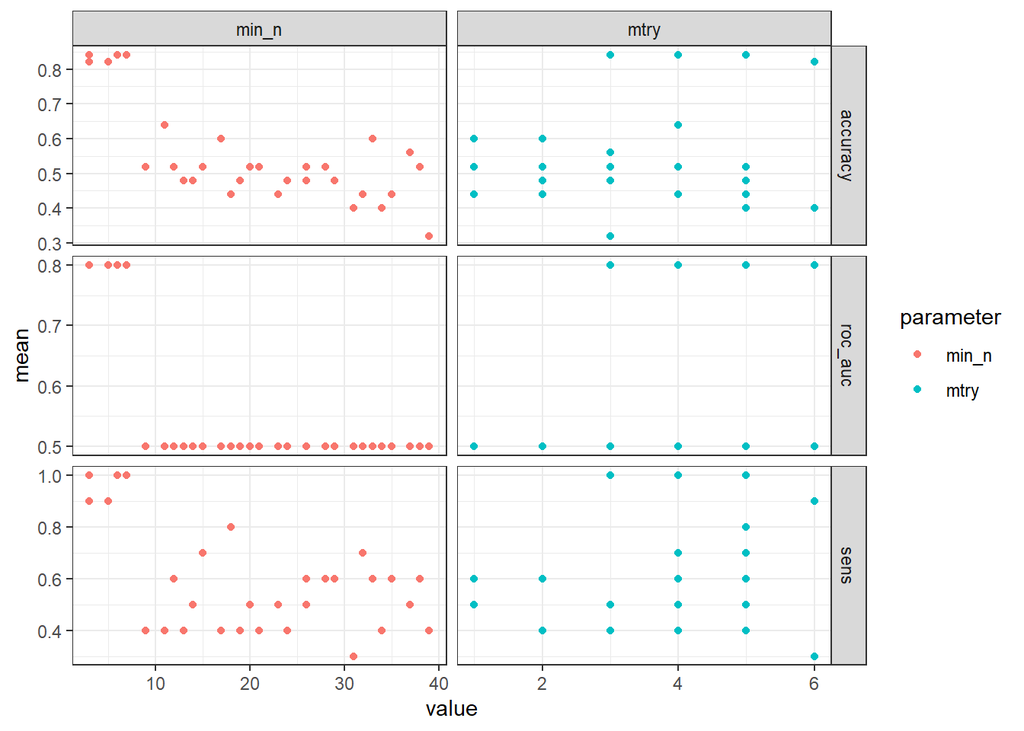

We will explore regular grid of min_n of 1 to 10 & mtry 3 to 5, to see if there is an optimal number. trying to pick highest roc,sens,and spec

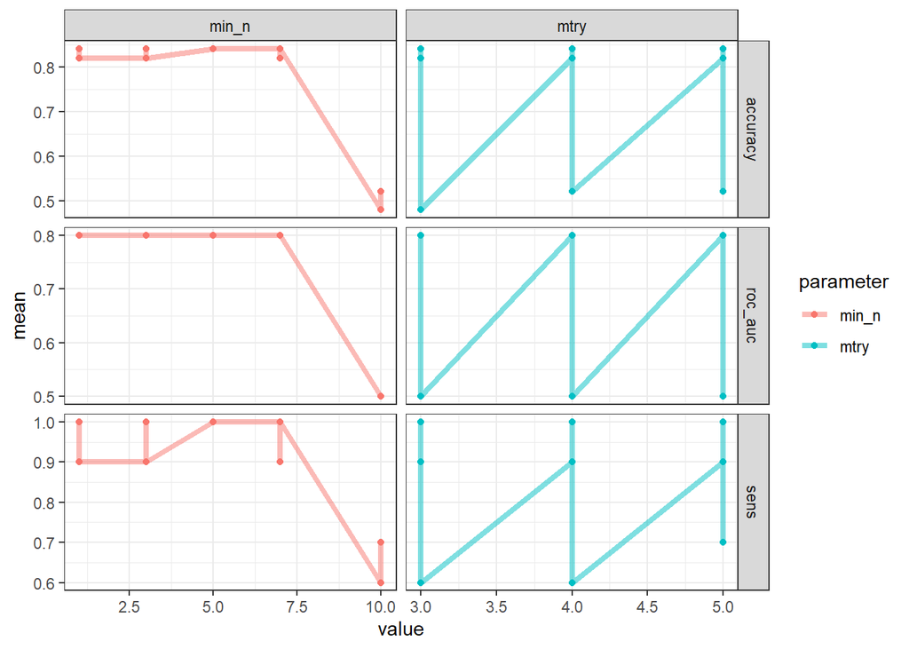

Looking for best fit, highest accuracy, ROC AUC and sensitivity. Let’s plug in min_n of 1 and mtry of 3

## random forest (tuning w min_n of 1 and mtry of 3)

```
## Random Forest Model Specification (classification)
##
## Main Arguments:
##   mtry = 3
##   trees = 100
##   min_n = 1
##
## Engine-Specific Arguments:
##   importance = impurity
##
## Computational engine: ranger
```

# Random Forest (tuned)

```
##           Truth
## Prediction No Yes
##        No   9   5
##        Yes  1  20
```

|  | .metric | .estimator | mean | n | std_err | .config |
| --- | --- | --- | --- | --- | --- | --- |
| 1 | accuracy | binary | 0.82 | 25 | 0.07 | Preprocessor1_Model1 |
| 2 | roc_auc | binary | 0.8 | 10 | 0.133333333333333 | Preprocessor1_Model1 |
| 3 | sens | binary | 0.9 | 10 | 0.1 | Preprocessor1_Model1 |
| 4 | spec | binary | 0.8 | 25 | 0.0816496580927726 | Preprocessor1_Model1 |

# Let’s compare all the models trained

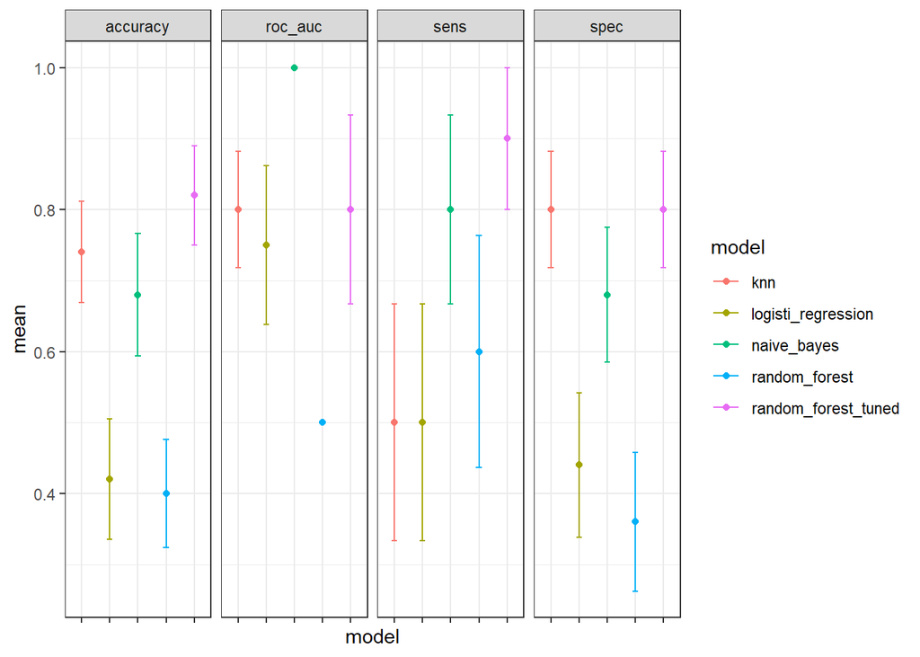

Looks like tuned random forest has the best result with balanced metrics

# Finalize our model and assess with test set

```r
set.seed(1)
final_wf <- workflow() %>%
  add_recipe(ite2_recipe) %>%
  add_model(rftuneres)

finalres <- final_wf %>%
  last_fit(split)

finalres %>%
  collect_predictions() %>%
  conf_mat(Pass, .pred_class)
```

```
##           Truth
## Prediction No Yes
##        No   0   1
##        Yes  1   1
```

```r
finalres %>%
  collect_metrics() %>%
  datatable()
```

|  | .metric | .estimator | .estimate | .config |
| --- | --- | --- | --- | --- |
| 1 | accuracy | binary | 0.333333333333333 | Preprocessor1_Model1 |
| 2 | roc_auc | binary | 0.5 | Preprocessor1_Model1 |

```r
final_model <- fit(final_wf, ite2)
final_model
```

```
## == Workflow [trained] ==========================================================
## Preprocessor: Recipe
## Model: rand_forest()
##
## -- Preprocessor ----------------------------------------------------------------
## 2 Recipe Steps
##
## * step_upsample()
## * step_normalize()
##
## -- Model -----------------------------------------------------------------------
## Ranger result
##
## Call:
##  ranger::ranger(x = maybe_data_frame(x), y = y, mtry = min_cols(~3L,      x), num.trees = ~100, min.node.size = min_rows(~1L, x), importance = ~"impurity",      num.threads = 1, verbose = FALSE, seed = sample.int(10^5,          1), probability = TRUE)
##
## Type:                             Probability estimation
## Number of trees:                  100
## Sample size:                      14
## Number of independent variables:  6
## Mtry:                             3
## Target node size:                 1
## Variable importance mode:         impurity
## Splitrule:                        gini
## OOB prediction error (Brier s.):  0.1207406
```

Looks like it didn’t do too well with our test data, unfortunately. Likely due to lack of overall data

# Final Model

I favor a tuned Random Forest. I will use the entire dataset to train our final model

```
## == Workflow [trained] ==========================================================
## Preprocessor: Recipe
## Model: rand_forest()
##
## -- Preprocessor ----------------------------------------------------------------
## 2 Recipe Steps
##
## * step_upsample()
## * step_normalize()
##
## -- Model -----------------------------------------------------------------------
## Ranger result
##
## Call:
##  ranger::ranger(x = maybe_data_frame(x), y = y, mtry = min_cols(~3L,      x), num.trees = ~100, min.node.size = min_rows(~1L, x), importance = ~"impurity",      num.threads = 1, verbose = FALSE, seed = sample.int(10^5,          1), probability = TRUE)
##
## Type:                             Probability estimation
## Number of trees:                  100
## Sample size:                      14
## Number of independent variables:  6
## Mtry:                             3
## Target node size:                 1
## Variable importance mode:         impurity
## Splitrule:                        gini
## OOB prediction error (Brier s.):  0.1207406
```

# Predict current learners

Let’s try to predict random ITE scores:

## Prediction using our trained model

|  | .pred_No | .pred_Yes | PGY1_percentile | PGY1_score | PGY2_percentile | PGY2_score | PGY3_percentile | PGY3_score |
| --- | --- | --- | --- | --- | --- | --- | --- | --- |
| 1 | 0.76 | 0.24 | 60 | 70 | 30 | 50 | 5 | 50 |
| 2 | 0.3 | 0.7 | 50 | 80 | 20 | 60 | 10 | 60 |

For further reading please go to https://www.tidymodels.org/start/